# Reproducible Research: Peer Assessment 1

The following report details the analysis of 61 days of data taken between October 1 and November 30, 2012. Each day during this period, a single individual recorded how many step they took throughout the day. Step counts were recorded in 5-minute intervals (288 observations per day). The original, unprocessed (by this analyst) data was made available through the Coursera Reproducible Data course downloaded on January 14, 2015 from here: https://d396qusza40orc.cloudfront.net/repdata%2Fdata%2Factivity.zip. It is available in the GitHub repository holding the files for this analysis.

## Loading and preprocessing the data

[output not shown]

[output not shown]

Data was loaded into R; date data were coerced into date format, and the result was converted into a data fram tbl for use with dplyr.

```r
mData <- read.csv("activity.csv", stringsAsFactors = FALSE)
mData$date <- as.Date(mData$date)
mData <- tbl_df(mData)
```

## What is mean total number of steps taken per day?

The data was grouped by day and summarized by summing each 5-minute interval for each day to calculate a single sum for each of the 61 days. The figure below is a histogram of the steps taken each day. For this quick peak at the data, NAs were simply ignored. The bin width is 1000 steps and the red line indicates the mean number of steps.

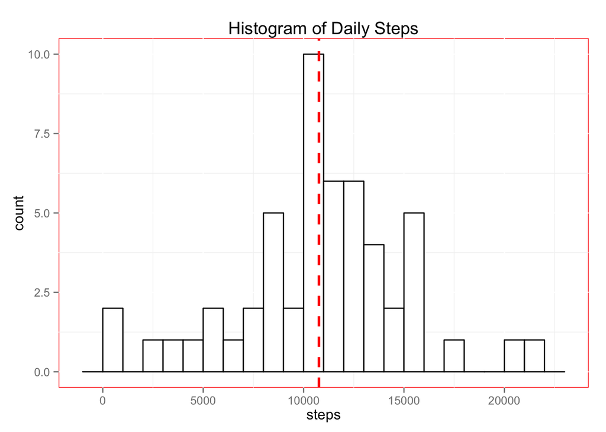

```r
byDayNA <- group_by(mData, date)
sumDayNA <- summarize(byDayNA, steps = sum(steps))
ggplot(sumDayNA, aes(x=steps)) +
        geom_histogram(binwidth=1000, colour="black", fill="white") +
        ggtitle("Histogram of Daily Steps") +
        theme(panel.background = element_rect(fill = 'white', colour = 'red')) +
        geom_vline(aes(xintercept=mean(steps, na.rm=T)), color="red", linetype="dashed", size=1)
```

The mean and median steps taken are displayed in the following table:

```r
meanStepsNA <- mean(sumDayNA$steps, na.rm=TRUE)
medStepsNA <- median(sumDayNA$steps, na.rm=TRUE)
Table1 <- matrix(c(meanStepsNA, medStepsNA), ncol=2, byrow=TRUE)
colnames(Table1) <- c("MEAN", "MEDIAN")
rownames(Table1) <- c("")
Table1 <- as.table(Table1)
Table1
```

```
##      MEAN   MEDIAN
##  10766.19 10765.00
```

## What is the average daily activity pattern?

In order to get a general picture of what the average day looked like for the subject, we first calculated, and then plotted the mean steps per interval (e.g., “How many steps did the participate take, on average, at 12:00AM, at 12:05, …at 11:55PM”)

```r
intData <- mData %>%
        group_by(interval) %>%
        summarize(meanSteps = mean(steps, na.rm = TRUE))
```

From this data, the following time series was generated:

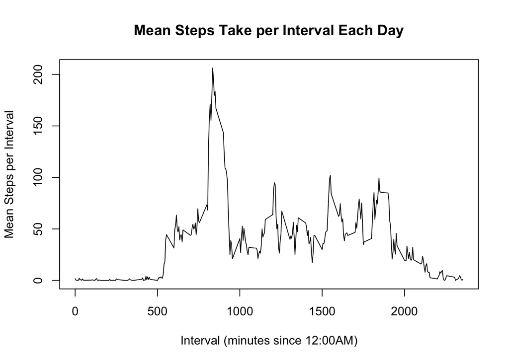

```r
plot(intData$meanSteps ~ intData$interval, type="l", xlab="Interval (minutes since 12:00AM)", ylab="Mean Steps per Interval", main="Mean Steps Take per Interval Each Day")
```

```r
arrange(intData, desc(meanSteps))[(1:5),]
```

```
## Source: local data frame [5 x 2]
##
##   interval meanSteps
## 1      835  206.1698
## 2      840  195.9245
## 3      850  183.3962
## 4      845  179.5660
## 5      830  177.3019
```

## Imputing missing values

Missing values may be biasing the report. First it was determined how many missing observations there were.

```r
mInt <- sum(is.na(mData))
mDay <- sum(is.na(sumDayNA))
Table2 <- matrix(c(mInt, mDay), ncol=1, byrow=TRUE)
colnames(Table2) <- c("")
rownames(Table2) <- c("Missing Intervals: ", "Missing Days: ")
Table2 <- as.table(Table2)
Table2
```

```
##
## Missing Intervals:  2304
## Missing Days:          8
```

Having determined that eight days (a total of 2,304 intervals) were missing, a method was deviced to replace the NAs. Although this can be done a variety of ways, the method chosen here was to replace each missing interval with the previously calculated average for that interval.

To do this, the interval averages were merged with the processed data set. (The “interval” column was removed to avoid duplication after merging.)

```r
intData <- select(intData, meanSteps)
mData2 <- cbind(mData, intData)
for (i in 1:17568) {
        if (is.na(mData2$steps[i])) {
                mData2$newSteps[i] <- mData2$meanSteps[i]
        } else {mData2$newSteps[i] <- mData2$steps[i]
        }
}
mData2 <- select(mData2, newSteps, date, interval)
```

From this new dataset, a new histogram was generated.

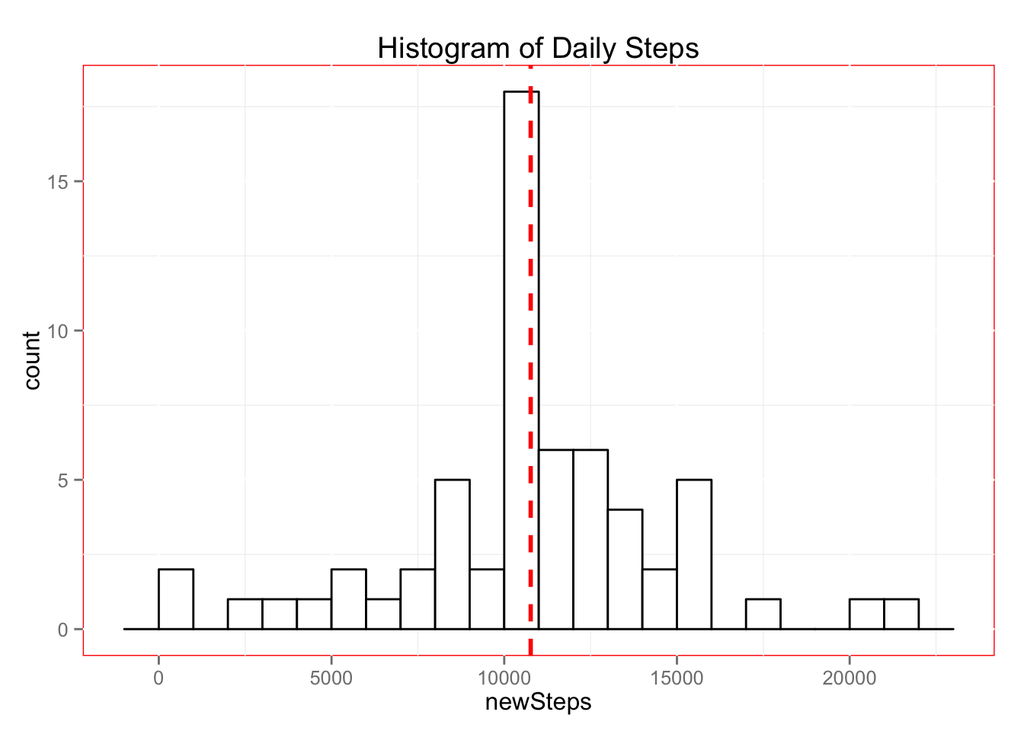

```r
byDay <- group_by(mData2, date)
sumDay <- summarize(byDay, newSteps = sum(newSteps))
meanSteps <- mean(sumDay$newSteps)
medSteps <- median(sumDay$newSteps)
ggplot(sumDay, aes(x=newSteps)) +
        geom_histogram(binwidth=1000, colour="black", fill="white") +
        ggtitle("Histogram of Daily Steps") +
        theme(panel.background = element_rect(fill = 'white', colour = 'red')) +
        geom_vline(aes(xintercept=mean(newSteps, na.rm=T)), color="red", linetype="dashed", size=1)
```

To determine if the mean truly is the same, the new and old medians and means are including in the table below:

```r
Table3 <- matrix(c(meanStepsNA, medStepsNA, meanSteps, medSteps), ncol=2, byrow=TRUE)
colnames(Table3) <- c("MEAN", "MEDIAN")
rownames(Table3) <- c("Previous Values", "with Imputed Values")
Table3 <- as.table(Table3)
Table3
```

```
##                         MEAN   MEDIAN
## Previous Values     10766.19 10765.00
## with Imputed Values 10766.19 10766.19
```

## Are there differences in activity patterns between weekdays and weekends?

Finally, the subject’s weekday habits were compared to his weekend habits. In order to do this, a new factor was added to the dataset grouping each day into those two categories (Monday- Friday = “weekday”; Saturday & Sunday = “weekend”.)

```r
for (i in 1:17568) {
        if (weekdays(mData2$date[i]) == "Saturday") {
                mData2$day[i] <- "weekend"
        } else if (weekdays(mData2$date[i]) == "Sunday") {
                mData2$day[i] <- "weekend"
        } else mData2$day[i] <- "weekday"
}
mData2$day <- as.factor(mData2$day)

weekdays <- filter(mData2, day == "weekday") %>%
        group_by(interval) %>%
        summarize(mean = mean(newSteps))

weekends <- filter(mData2, day == "weekend") %>%
        group_by(interval) %>%
        summarize(mean = mean(newSteps))

days <- group_by(mData2, interval, day) %>%
        summarize(meanSteps = mean(newSteps))
```

A panel plot was made to easily compare these two sets and make any variation between the two more obvious:

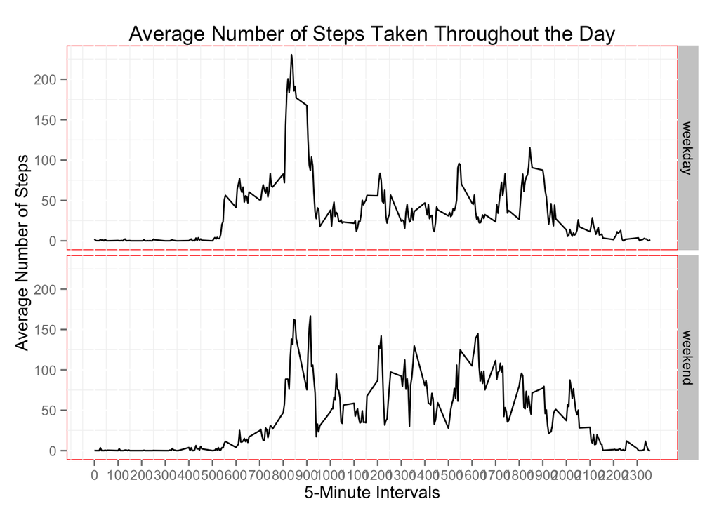

```r
ggplot(data = days, mapping = aes(x = interval, y = meanSteps)) +
        geom_line() + facet_grid(day ~ .) + scale_x_continuous("5-Minute Intervals",
        breaks = seq(min(days$interval), max(days$interval), 100)) +
        theme(panel.background = element_rect(fill = 'white', colour = 'red')) +
        scale_y_continuous("Average Number of Steps") +
        ggtitle("Average Number of Steps Taken Throughout the Day")
```